# Lab B2

STA 198 Summer 2020 (Jiang)

Bonus lab: R Shiny

This lab will introduce the basics of creating interactive, web-based apps using R Shiny. This lab is not graded, as it is rather meant to serve as a resource for your data science career (and may be helpful on your final project!).

# Shiny?

Shiny is an R package used to build web-based apps with R in RStudio. Shiny can incorporate CSS themes and JavaScript actions. To see some existing apps in action, check out the [Shiny Gallery linked here](https://shiny.rstudio.com/gallery/). Once created, you can easily share your app with others! You can upload it to `shinyapps.io`, which allows you to create and publish your app. With a free account, you get 5 active applications, with 25 hours per month of active use.

To create a Shiny app, instead of coding in an .Rmd file (markdown), we will code using an R script (.R) file. Note that you may have to install the package using

```r
install.packages("shiny")
```

To create a new Shiny App, go to `File > New File > Shiny Web App` and follow the on-screen prompts. Make sure to keep the option Single File (app.R) selected. You should see that the file `app.R` will open – click on Run App to see the result.

Some examples are included in the `shiny` package. Enter any of the following code in the Console to see the app in action (along with the code):

```r
runExample("01_hello")        # a histogram
runExample("02_text")         # tables and data frames
runExample("03_reactivity")   # a reactive expression
runExample("04_mpg")          # global variables
runExample("05_sliders")      # slider bars
runExample("06_tabsets")      # tabbed panels
runExample("07_widgets")      # help text and submit buttons
runExample("08_html")         # Shiny app built from HTML
runExample("09_upload")       # file upload wizard
runExample("10_download")     # file download wizard
runExample("11_timer")        # an automated timer
```

There are a few basic components in a Shiny app, the user-interface, which specifies what the user experiences, the server logic, which gives the behind- the-scenes operations, and a function to build and run the application:

```r
library(shiny)

# Define UI:
ui <- fluidPage(

)

# Define server logic
server <- function(input, output){

}

# Build and run the application
shinyApp(ui = ui, server = server)
```

The `fluidPage()` function creates a dynamic HTML user interface that you see when you look at an app. The `server()` function contains the R commands your computer (or external server) uses to run the app. Finally, the function `shinyApp()` builds the app based on the user interface and server code.

# Building a Shiny app

- First, we’ll construct the UI, focusing on the widgets and layout design
- Next, we’ll learn how to connect the input widgets and outputs with the code by using the `server` function
- And finally, we’ll run the app itself

## User interface: inputs

The user inputs essentially collect values from the user. These can be any sort of data – continuous, categorical, dates, etc. These inputs are added as **widgets** to the Shiny app, and most input widgets are set-up as

```r
___Input(inputId, label, ...)
```

or

```r
___Button(inputId, label, ...)
```

For instance, to create a slider widget labeled “Number of bins” that controls the number of bins, ranging from 1 to 50, we can use the following code:

```r
sliderInput(inputId = "bins", label = "Number of bins:",
            min = 1, max = 50, value = 30)
```

This code creates the following input:

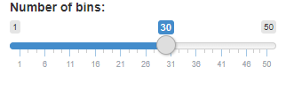

Notice the `inputId`. This tells Shiny what this input widget is named, and will be important when connecting it to the server code later. This name is not seen by the end-user, but the `label` is.

Examples of input widgets are given below. The first and second arguments of the function will always be `inputId` and `label`, but the remaining arguments depend on what exactly is being inputed. For further details, consult the help documentation.

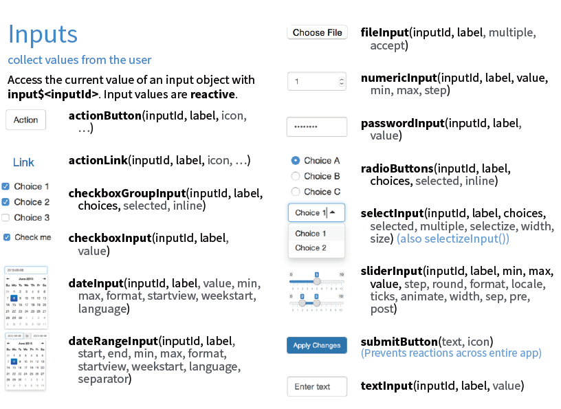

Note that if you run the `sliderInput` code in the Console directly, you will actually see some HTML code!

Let’s take a look at some more input widgets and what they correspond to on the user’s side. Note that you can add as many widgets as you want/need.

```r
ui <- fluidPage(
  # add slider
  sliderInput("bins", "Number of bins:",
              min = 1, max = 50, value = 30),

  # text box input
  textInput("title", "Histogram title",
            value = "Histogram"),

  # combo box
  selectInput("color", "Histogram fill",
              choices = c("Red", "White", "Blue"),
              selected = "Red")
)

server <- function(input, output) {

}

shinyApp(ui = ui, server = server)
```

The picture below corresponds to the code above.

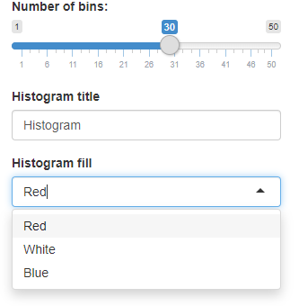

## User interface: outputs

Just as inputs are added as `___Input()`, outputs in Shiny are added with `___Output()`. These can be data tables, raw HTML, plots, tables, etc. A table of what each output function creates is below:

| Output function | Creates |
| --- | --- |
| `dataTableOutput()` | data table |
| `htmlOutput()` | raw HTML |
| `imageOutput()` | image |
| `plotOutput()` | plot |
| `tableOutput()` | table |
| `textOutput()` | text |
| `uiOutput()` | raw HTML |
| `verbatimTextOutput()` | text |

Similarly to the inputs, the first argument for each output function is `outputId`, which is where you specify a name of the output (not seen by the user). Again, this name will serve as a reference when the `server()` function runs the code.

Note that the output function is still part of the `ui` that is created. Let’s take a look at an example of an output function that corresponds to the `sliderInput()` object we created earlier:

```r
ui <- fluidPage(
  # add slider
  sliderInput("bins", "Number of bins:",
              min = 1, max = 50,
              value = 30),

  plotOutput(outputId = "hist")
)

server <- function(input, output) {
}

shinyApp(ui = ui, server = server)
```

The code `plotOutput(outputId = "hist")` allocates space for a plot. However, since we haven’t actually created anything yet, no plot is visible:

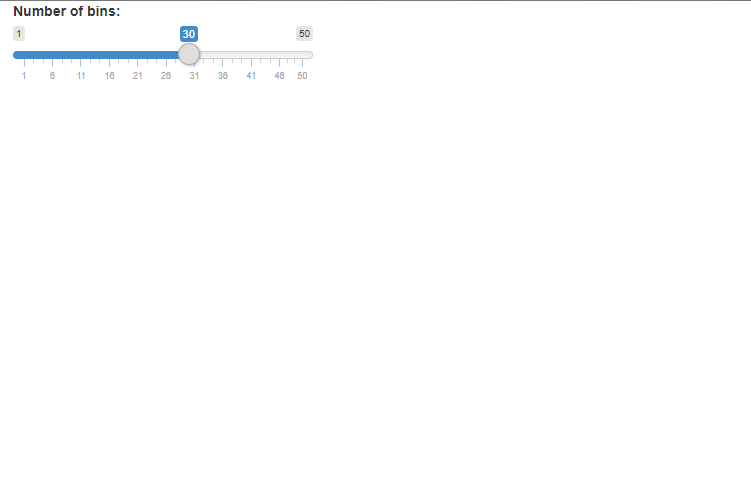

Note that each separate input and output is separated by a comma in the `fluidPage` function, which we will use to create the `ui` object.

Let’s create a UI object for our Brexit poll app. First, load in the data and packages, and do a bit of data cleaning.

```r
library(shiny)
library(shinythemes)
library(dslabs)
library(DT)
data("brexit_polls")
pollsters <- brexit_polls %>%
    count(pollster) %>%
    pull(pollster) %>%
    as.character()

# Define the user interface
ui <- fluidPage(

)
```

1. Create a `ui` object that corresponds to the user interface in the picture below. **Hint:** This `ui` object should use a `sidebarLayout()` with a `sidebarPanel()` and `mainPanel()`, have a theme from the `shinythemes` package, and have two input widgets (`dateRangeInput()` and `selectInput()`) and two outputs (`plotOutput()` and `dataTableOutput()`).

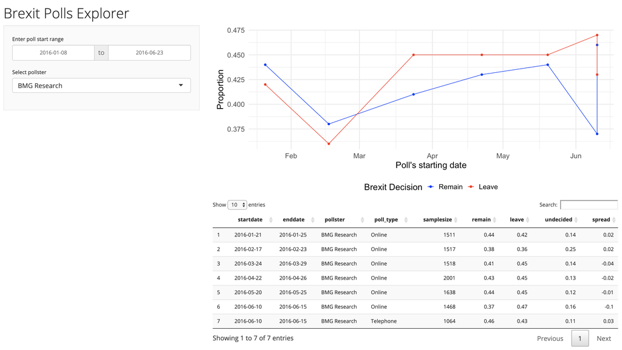

## The server function

You may notice that you have a user interface built, but it doesn’t *do* anything. How was the plot and table in the image created for Exercise 1?

You need to give R commands that react when inputs ar eprovided or are changed. These reactions are seen by updates to the outputs. Take a look at the [link given here](https://shiny.rstudio.com/gallery/tabsets.html). As you change the inputs, look at what is highlighted in the `server()` function below. You will create your own `server` function to do similar tasks.

The `server` function plays a special role: it builds a list-like object named `output` that contains all of the code needed to update the R objects in your app. Each R object needs to have its own entry in the list. You can create an entry by defining a new element for output within the server function. The element name should match the name of the reactive element that you created in the user interface. This is where the `inputId`s and `outputId`s that you defined earlier in your `ui` widgets and outputs come into play.

To create the `server()` function, follow the three steps below:

- First, save objects to display to `output$<outputId>`, where `<outputId>` is the name given from the `___Output` function from earlier. For instance:

```r
server <- function(input, output) {
  output$hist <- # code
}
```

- Next, build these `output$<outputId>` objects with the `render___()` family of functions. For instance:

```r
server <- function(input, output) {
  output$hist <- renderPlot({
    # code to build your object
    # in this case, code to create
    # the histogram
  })
}
```

Each output corresponds to a specific rendering function, given in the following table. Note that each `render___` function only requires a single argument: an R expression surrounded by braces. This expression can be one simple line of code, or it can involve many different lines of code.

| Render function | Creates a reactive |
| --- | --- |
| `renderDataTable()` | data table |
| `renderImage()` | image |
| `renderPlot()` | plot |
| `renderPrint()` | version of the given function that captures print output |
| `renderTable()` | table |
| `renderText()` | version of the given function to turn its result into a character vector. |
| `renderUI()` | HTML |

The relationship between each output and what “renders” the output is summarized in the graphic below:

[figure not shown]

- Finally, access your input values with `intput$<inputId>`, where `<inputId>` is the name provided from your `___Input()` function from the `ui`.

Assuming a well-built Shiny app, every time the user moves the slider, selects a value in a combo box, selects a new radio button option, outputs will automatically get updated when inputs change. This is known as reactivity. Reactivity automatically occurs whenever you use an input value to render an output object.

2. Create a `server` function that corresponds to the user-interface defined earlier. Use `renderPlot()` to display a reactive plot that depends on the date range and pollster inputs, and `DT::renderDataTable()` to display a reactive table that depends on the date range and pollster inputs, sorted by start date.

# Solutions

If you’d like to see the `ui` function and `server` function as implemented for the Brexit poll example above, you can click on the following button. However, do try to create the app before viewing the solution. As a reminder, the UI and output to be created are given in the following screenshot:

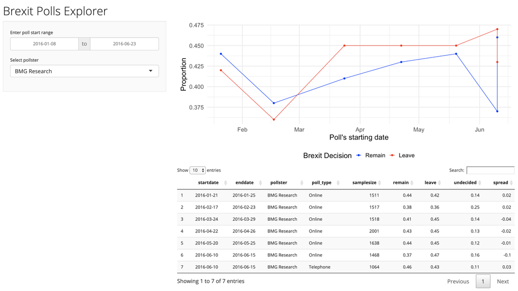

```r
# Define the user interface
ui <- fluidPage(theme = shinytheme("yeti"),
    # Application title
    titlePanel("Brexit Polls Explorer"),
    # sidebar
    sidebarLayout(
        sidebarPanel(
            dateRangeInput(inputId = "daterange",
                           label   = "Enter poll start range",
                           start   = "2016-01-08",
                           end     = "2016-06-23",
                           min     = "2016-01-08",
                           max     = "2016-06-23"),
            selectInput(inputId  = "pollster",
                        label    = "Select pollster",
                        choices  = pollsters)
        ),
        # main panel
        mainPanel(
           plotOutput(outputId = "plotpolls"),
           dataTableOutput(outputId = "tablepolls")
        )
    )
)

# Create server function
server <- function(input, output) {
    output$plotpolls <- renderPlot({
        brexit_polls %>%
            filter(startdate >= input$daterange[1],
                   startdate <= input$daterange[2]) %>%
            filter(pollster == input$pollster) %>%
            ggplot(aes(x = startdate, y = remain)) +
            geom_point(aes(color = "blue"), size = 2) +
            geom_line(aes(color = "blue")) +
            geom_point(aes(y = leave, color = "red"), size = 2) +
            geom_line(aes(y = leave, color = "red")) +
            labs(x = "Poll's starting date", y = "Proportion") +
            theme_minimal(base_size = 20) +
            theme(legend.position = "bottom") +
            scale_color_identity(name   = "Brexit Decision",
                                 breaks = c("blue", "red"),
                                 labels = c("Remain", "Leave"),
                                 guide  = "legend")
    })
    output$tablepolls <- DT::renderDataTable({
        brexit_polls %>%
            filter(startdate >= input$daterange[1],
                   startdate <= input$daterange[2]) %>%
            filter(pollster == input$pollster) %>%
            arrange(startdate)
    })
}

shinyApp(ui = ui, server = server)
```

# References

- Shiny. (2019). https://shiny.rstudio.com.